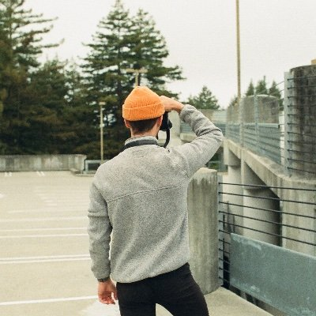

# Roman E. Reggiardo (He/Him)

## News

2022-08 – I just wrapped up teaching the 2022 UCSC Genomics Institute Summer Short Course in Bioinformatics, check out the course material and website [here](https://rreggiar.github.io/ucsc_scbc_2022/).

2022-07 – Our work on mutant KRAS-driven epigenomic changes in early tumorigenesis is out now published in *Cell Reports*!

## Bio

Hello! I’m finishing my PhD in Bioengineering and Bionformatics at UC Santa Cruz under supervision of Assistant Professor Daniel Kim. I am an **NIH F99/K00 fellow supported by the NIDDK-KUH** to complete my thesis work (F99) developing novel RNA liquid biopsies for the non-invasive detection and characterization of Lung and Pancreatic cancers and have an additional (K00) 4-years of funding to expand extracellular RNA research into hematological applications.

In addition to my academic training, I have also **interned with (and currently consult for) Bluestar Genomics**, one of the leaders in commercial liquid biopsy technology.

My expertise is in bioinformatics and applied machine learning/statistics – techniques I have used to help advance academic (RNA) and industrial (DNA) liquid biopsy approaches.

I’ll soon be seeking Post Doctoral positions that enable my K00-supported research and my continued growth as a scientist, mentor, and human.

Summer 2022 I’ll be running a UCSC Genomics Institute-sponsored Bioinformatics Short-course for primarily Community College students and writing a report as a Baskin Engineering Anti-Racist Research fellow.

Additionally, I’ll be deciding on the destination for my post-doc.

## Education

- [CV](https://github.com/rreggiar/rreggiar.github.io/blob/7cc88cea19990c5723a14d8e30f021fd59341d52/docs/roman_reggiardo_CV_07_2022.pdf)

**University of California, Santa Cruz** | Santa Cruz, CA

Ph.D. in Bioengineering & Bioinformatics | September 2017 - May 2023 (est.)

**University of California, Santa Cruz** | Santa Cruz, CA

B.S. in Biochemistry and Molecular Biology | September 2012 - June 2017

## Resources

- [UCSC SCBC 2022 course](https://rreggiar.github.io/ucsc_scbc_2022/)

## Support

**NIDDK-KUH F99/K00** | Fellow | September 2021 - September 2026 (est.)

## Other Experience

**UCSC Baskin School of Engineering Anti-Racist Research** | Fellow | Summer 2022

**UCSC GI Summer Short-course in Bioinformatics** | Lead Facilitator | Summer 2022

**UCSC GI Diversity, Equity, and Inclusion Committee** | Member | Spring 2022 - 2023

**UCSC CITL Graduate Pedagogy** | Fellow | Winter 2022 - 2023

**Bionformatics Scientist** | Intern > Consultant | June 2021 - Present

**Teaching Assistant for:** Data Viz, Stem Cell Biology, Molecular Biology Lab, Intro to Comp. Bio, and more …

*I made this with postcards*